# Experiments CMI & HiCS

Ines Machinek

December 6th, 2016

## Comparing CMI, HiCS and GMD Subspace Search using real-world datasets

### Overview

This document contains the results of a comparison of the algorithms CMI, HiCS & GMD. For further documentation, see:

- ```
  Nguyen, Hoang, Vreeken, Jilles, Mueller, Emmanuel, Keller, Fabian and Klemens Boehm. 2013.
  "CMI: An Information-Theoretic Contrast Measure for Enhancing Subspace Cluster and Outlier Detection"
  ```

- ```
  Keller, Fabian, Emmanuel Mueller, and Klemens Boehm. 2012. "HiCS: High Contrast Subspaces for Density-Based Outlier Ranking." In 2012 IEEE 28th
  International Conference on Data Engineering, 1037-48. IEEE.
  ```

CMI and HiCS algorithms were implemented in inline c++ in R, using the Rcpp-package. Experiments ran on Intel core i7-4600U CPU and 8 GB RAM.

For implementation details see [R-Subcon](https://github.com/holtri/Rsubcon).

### Datasets

The datasets for testing were:

Datasets - Overview

| Datasets | Rows | Dimensions |
| --- | --- | --- |
| Ann Thyroid | 3772 | 6 |
| Diabetes | 768 | 8 |
| Glass | 214 | 7 |
| Ion | 351 | 32 |
| Lympho | 148 | 18 |
| Pendigits | 6737 | 16 |
| Segment | 2013 | 19 |

Datasets can be downloaded here: [IPD, KIT Karlsruhe](http://www.ipd.uni-karlsruhe.de/~muellere/HiCS/)

### Run Experiments

1. Download the datasets into the *datasets* folder
2. Source the *HICSvsCMI_Experiments.R* script
3. Start experiment by calling **runExperiments**-function, for example:

```r
  finalResult <- runExperiments(inputPath = "datasets", maxMinPts = 100, numCores=1, topkSearch = 500, topkOutput = 100)
```

Automatically a file *experimentResult.RData* will be written to the *results* folder. If you want to reuse the same structure of the KNITR-File for other experiments, please make sure that you’ve got 1 RMD-Resultfile per dataset.

Results can be loaded by

```r
load("results/experimentResult.RData")
```

### Results

The following results, unless otherwise noted, were observed after having run the algorithms with the parameters:  
* maxMinPts = 100  
* numCores = 1  
* topkSearch = 50  
* topkOutput = 20

#### AUC on real world data

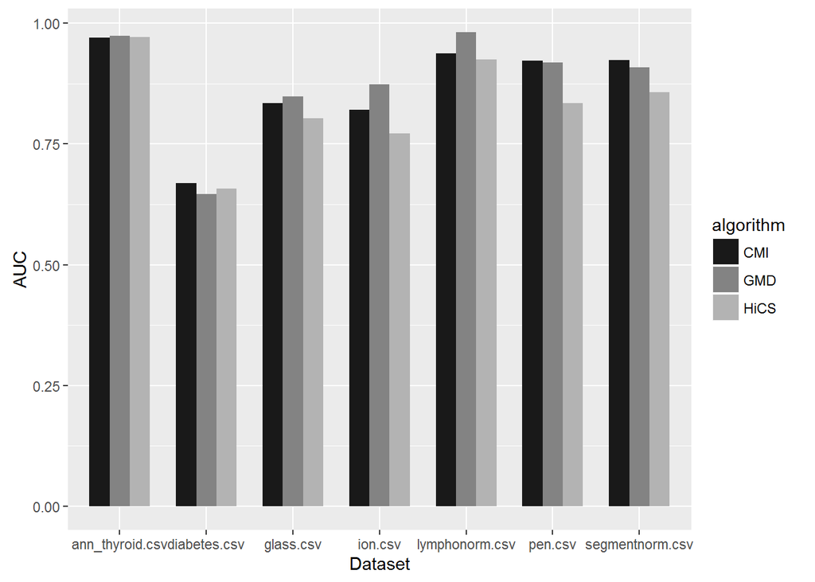

#### Runtime

The duration of subspace search algorithm and LOF calculation were the following:

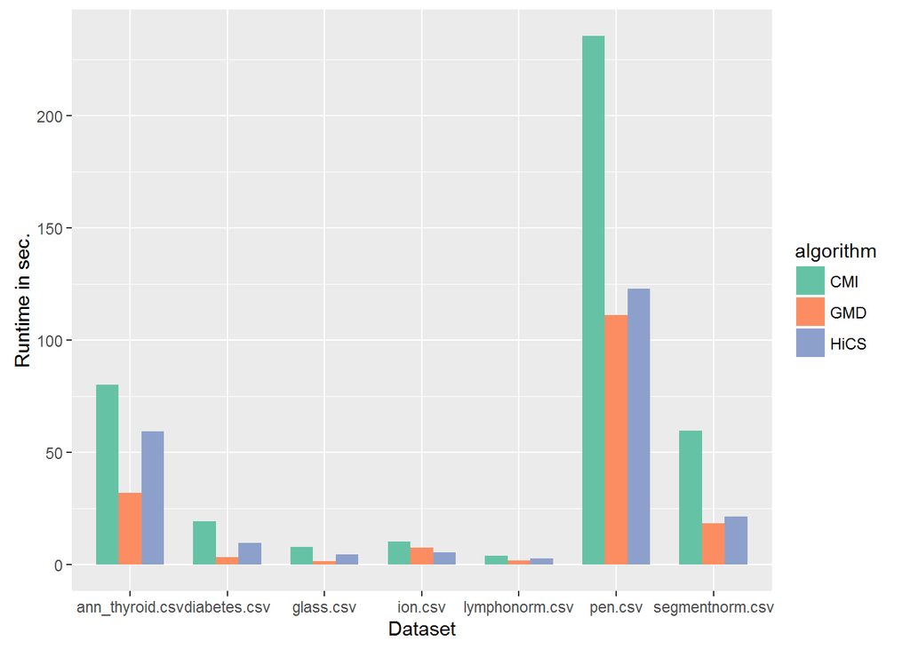

#### Subspaces

One aspect we considered was the size of the subspaces which were found by the algorithms.

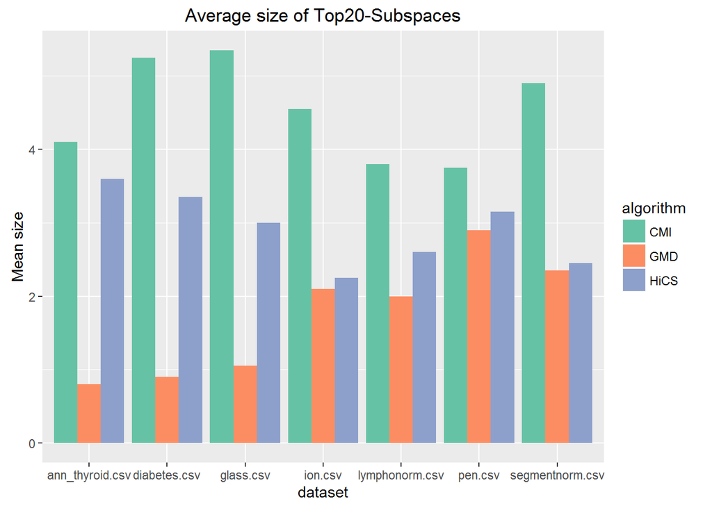

With CMI subspaces with higher dimensions were found. It is even more obvious when you look at the Top5 Subspaces.

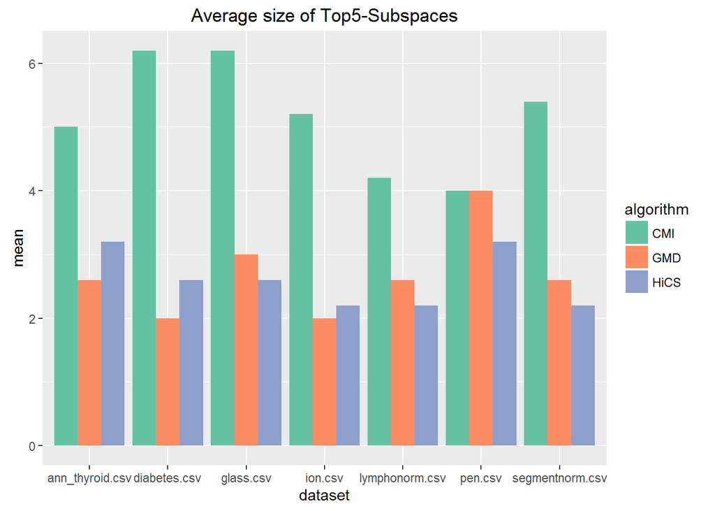

Some examples of found subspaces:

Top-5-Subspaces - Glass-Dataset

| Algorithm | Dataset | Subspace 1 | Subspace 2 | Subspace 3 | Subspace 4 | Subspace 5 |
| --- | --- | --- | --- | --- | --- | --- |
| HiCS | glass.csv | [2,5,7] | [2,5] | [5,6] | [1,2,5] | [1,5,6] |
| CMI | glass.csv | [1,2,3,4,5,6,7] | [2,3,4,5,6,7] | [1,3,4,5,6,7] | [1,2,3,4,5,6] | [1,2,3,4,5,7] |
| GMD | glass.csv | [1,5,3] | [2,5,7] | [3,6,7] | [4,3,7] | [5,2,7] |

Top-5-Subspaces - Ion-Dataset

| Algorithm | Dataset | Subspace 1 | Subspace 2 | Subspace 3 | Subspace 4 | Subspace 5 |
| --- | --- | --- | --- | --- | --- | --- |
| HiCS | ion.csv | [11,13] | [13,19] | [11,13,21] | [9,15] | [11,19] |
| CMI | ion.csv | [7,9,11,13,15,17] | [11,13,15,17,19] | [9,11,13,15,17] | [11,13,15,19,21] | [7,11,13,15,17] |
| GMD | ion.csv | [1,3] | [2,10] | [3,5] | [4,6] | [5,7] |

Top-5-Subspaces - Pendigits-Dataset

| Algorithm | Dataset | Subspace 1 | Subspace 2 | Subspace 3 | Subspace 4 | Subspace 5 |
| --- | --- | --- | --- | --- | --- | --- |
| HiCS | pen.csv | [4,6,8] | [10,12,14] | [10,12,14,16] | [8,10,12] | [12,14,16] |
| CMI | pen.csv | [6,8,10,12] | [6,8,14,16] | [6,8,12,14] | [8,12,14,16] | [8,9,10,11] |
| GMD | pen.csv | [1,5,4,11,3] | [2,6,4] | [3,4] | [4,3,6,2,16,8,7,5] | [5,2] |

The size of the subspaces is much higher for CMI than for HiCs and for GMD. A reason is maybe the higher score a subspace gets by adding further dimensions.

The global mean of subspace size is

```
## [1] 3.057143
```

Those are the mean sizes of subspaces per algorithm:

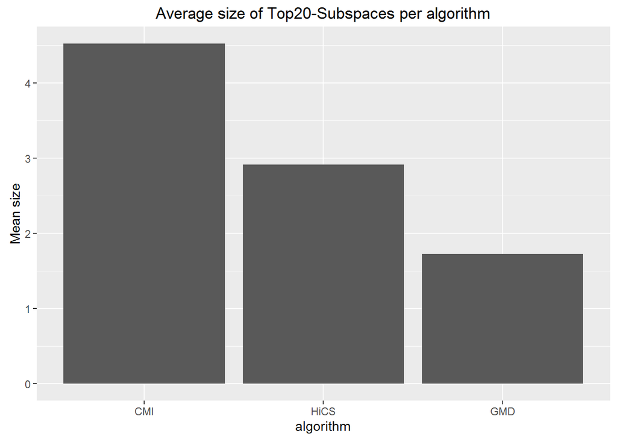